# ASDIA Projet 1

#### Etude d’association

Le but d’une étude d’association est d’identifier les termes les plus associés aux opinions positives ou négatives des utilisateurs. Pour cela, nous evaluons la correlation au carré entre l’occurrence de chaque terme et l’opinion de l’utilisateur (présence d’un 1). Il se peut que certaines valeurs de corrélation ne soient pas calculables à cause d’un écart-type nul.

- Calcul du coefficient de corrélation au carré entre les fréquences d’apparition des termes de l’index et opinion des utilsateurs (5000 valeurs).

```r
  # termes
  x <- x_imbd

  # opinion
  y <- y_imbd

  # comment
  r <- cor(x, y)
  r2 <- r^2
```

```r
  # quelque chose à changer
  index[o[ which(r2 > 0.03) + 48 ]] %>% names()
```

```
## [1] "bad"   "great" "worst" "awful" "waste"
```

```r
  index[o[ which(r2 > 0.02) + 48 ]] %>% names()
```

```
##  [1] "no"        "bad"       "great"     "best"      "nothing"
##  [6] "minutes"   "worst"     "excellent" "poor"      "awful"
## [11] "stupid"    "wonderful" "terrible"  "worse"     "waste"
```

```r
  index[o[ which(r2 > 0.01) + 48 ]] %>% names()
```

```
##  [1] "no"         "even"       "well"       "bad"        "great"
##  [6] "life"       "plot"       "acting"     "best"       "love"
## [11] "why"        "nothing"    "always"     "script"     "minutes"
## [16] "worst"      "money"      "1"          "beautiful"  "excellent"
## [21] "poor"       "boring"     "awful"      "stupid"     "wonderful"
## [26] "terrible"   "perfect"    "supposed"   "worse"      "waste"
## [31] "loved"      "oh"         "amazing"    "favorite"   "horrible"
## [36] "brilliant"  "crap"       "annoying"   "ridiculous" "dull"
## [41] "fantastic"  "lame"       "poorly"     "superb"     "mess"
## [46] "wasted"     "pointless"  "laughable"
```

On remarque que plus $r^2$ diminue, moins les mots permettent de se faire une idée sur l’opinion du commentateur. Par exemple, lorsque $r^2 > 0.03$, on trouve le terme “bad” qui nous indique que l’opinion est négative. Au contraire, lorsque $r^2 > 0.01$, on a par exemple les mots “life” ou “acting” qui ne permettent pas de classifier le commentaire.

- Dans quelles proportions les termes de valeur d’association $r^2$ supérieure à 0.02 apparaissent-ils dans les documents ? Représenter graphiquement ces proportions à l’aide d’un diagramme en barre.

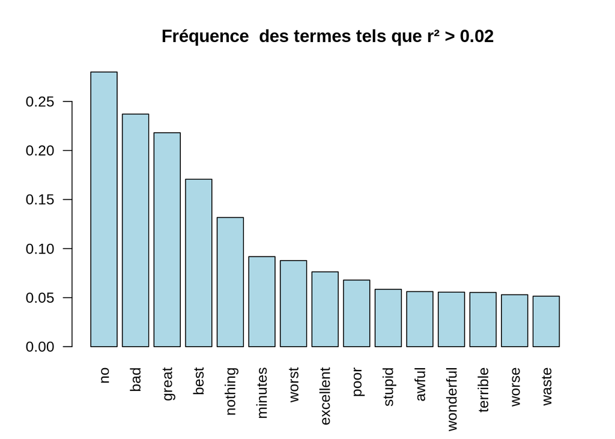

```
##        no       bad     great      best   nothing   minutes     worst
##    0.2800    0.2371    0.2181    0.1707    0.1317    0.0918    0.0878
## excellent      poor     awful    stupid wonderful  terrible     worse
##    0.0763    0.0679    0.0562    0.0585    0.0556    0.0553    0.0530
##     waste
##    0.0515
```

```r
title = " Fréquence  des termes tels que r² > 0.02"
# Calculer la frequence des termes realisant la condition
diag_freq = function(corr, color, title){
  ind <- c()
  list <- index[o[ which(r2 > corr) + 48 ]]
  for (i in 1:length(list)){
    ind[i]=list[[i]]
  }

  freq <- x[,ind] %>% apply(2, mean) #moyenne sur les colonnes
# mots dans l'index et barplot
  names(freq) <-  index[o[which(r2 > corr) + 48]] %>% names()
  b = barplot(sort(freq, decreasing = TRUE), col = color, las = 2, main = title)
  return(freq)
}


diag_freq(0.02, "lightblue", title)
```

- Dans quelles proportions les termes de valeur d’association $r^2$ supérieure à 0.01 apparaissent-ils dans les documents ? Représenter graphiquement ces proportions à l’aide d’un diagramme en barre.

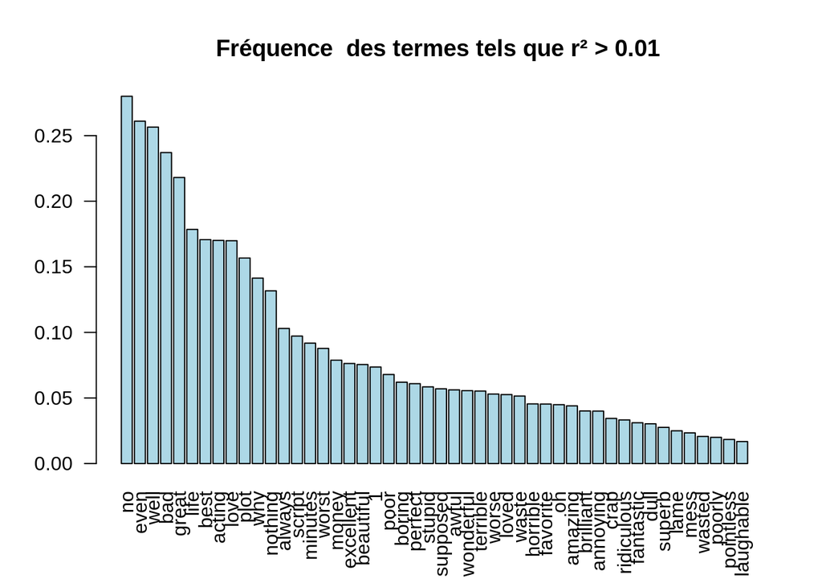

```
##         no       even       well        bad      great       life
##     0.2800     0.2610     0.2565     0.2371     0.2181     0.1785
##       plot     acting       best       love        why    nothing
##     0.1567     0.1701     0.1707     0.1699     0.1414     0.1317
##     always     script    minutes      worst      money          1
##     0.1030     0.0972     0.0918     0.0878     0.0788     0.0736
##  beautiful  excellent       poor     boring      awful     stupid
##     0.0755     0.0763     0.0679     0.0620     0.0562     0.0585
##  wonderful   terrible    perfect   supposed      worse      waste
##     0.0556     0.0553     0.0609     0.0570     0.0530     0.0515
##      loved         oh    amazing   favorite   horrible  brilliant
##     0.0526     0.0449     0.0440     0.0454     0.0455     0.0401
##       crap   annoying ridiculous       dull  fantastic       lame
##     0.0344     0.0400     0.0333     0.0303     0.0311     0.0250
##     poorly     superb       mess     wasted  pointless  laughable
##     0.0200     0.0276     0.0234     0.0207     0.0184     0.0168
```

```r
title = " Fréquence  des termes tels que r² > 0.01"
diag_freq(0.01, "lightblue", title)
```

- Dans quelles proportions les termes de valeur d’association $r = cor(x,y)$ supérieure à 0.1 apparaissent-ils dans les documents ? Représenter graphiquement ces proportions à l’aide d’un diagramme en barre.

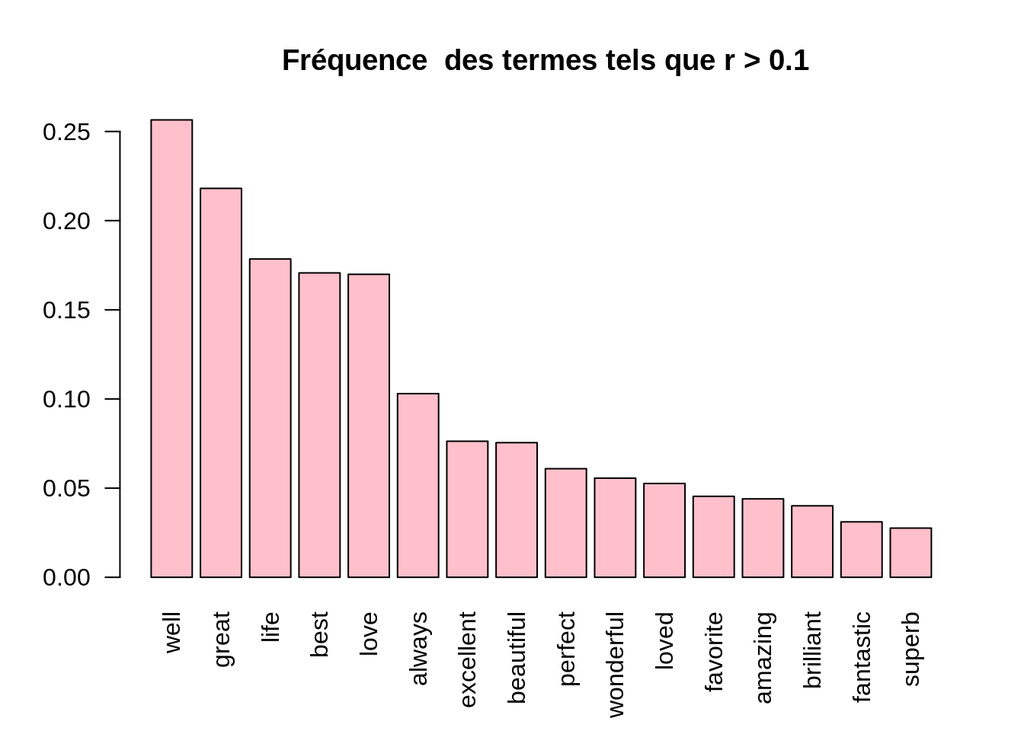

```r
ind <- c()
  list <- index[o[ which(r > 0.1) + 48 ]]
  for (i in 1:length(list)){
    ind[i]=list[[i]]
  }

  freq <- x[,ind] %>% apply(2, mean) #moyenne sur les colonnes
# mots dans l'index et barplot
  names(freq) <-  index[o[which(r > 0.1) + 48]] %>% names()
  b = barplot(sort(freq, decreasing = TRUE), col = "pink", las = 2, main = " Fréquence  des termes tels que r > 0.1")
```

- Dans quelles proportions les termes de valeur d’association $r$ inférieure à $-0.1$ apparaissent-ils dans les documents ? Représenter graphiquement ces proportions à l’aide d’un diagramme en barre.

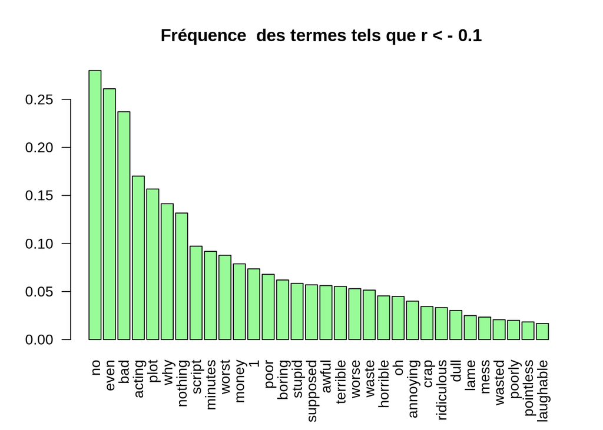

```r
ind <- c()
list <- index[o[ which(r < -0.1) + 48 ]]
  for (i in 1:length(list)){
    ind[i]=list[[i]]
  }

freq <- x[,ind] %>% apply(2, mean) #moyenne sur les colonnes
# mots dans l'index et barplot
names(freq) <-  index[o[which(r < -0.1) + 48]] %>% names()
barplot(sort(freq, decreasing = TRUE), col = "palegreen", las = 2, main = " Fréquence  des termes tels que r < - 0.1")
```

Apriori, plus on a de termes dont la corélation avec y est positive, plus le commentaire a de chances d’être négatif. Or on observe ici des termes à connotations négatives dont la corélation avec y est négative, et inversement pour les termes positifs, ce qui étonne nos scientifiques, y compris les plus doués.

#### Modèles d’apprentissage

Voici le code R correspondant au modèle qu’on a choisi:

```r
set.seed(seed = 5427381)
x_train <- x[1:5000,]
x_test <- x[5001:10000,]
y_train <- y[1:5000]
y_test <- y[5001:10000]

val_dropout = 0.5
nb_neurones = 10
nb_couches = 10
# code de mon meilleur modèle
model<-keras_model_sequential()

# Initialisation de la première couche avec fonction d'activation "relu" et 256 neurones.
model %>%
layer_dense(units = nb_neurones, activation = 'relu', input_shape = 5000) %>%
layer_dropout(rate = val_dropout) %>%

# Initialisation des couches suivantes
for(i in 1: nb_couches){
  model %>%
  layer_dense(units = nb_neurones, activation = 'relu') %>%
  layer_dropout(rate = val_dropout)
}

# Initialisation de ladernière couche
model %>%
layer_dense(units = 1, activation = 'sigmoid')


# Configuration du modèle pour l'apprentissage
model %>% compile(
          loss = 'binary_crossentropy',
          optimizer = optimizer_rmsprop(lr = 0.001, rho = 0.9, decay = 0),
          metrics = c('accuracy')
      )

# Entraînement du réseau
history <- model %>% fit(
                          x_train,
                          y_train,
                          epochs = 20,
                          batch_size = 500,
                          validation_data = list(x_test, y_test))

# Evaluation du modèle
model %>% evaluate(x_test, y_test)
```

```
## $loss
## [1] 0.3471773
##
## $acc
## [1] 0.863
```

[output not shown]

Ainsi après plusieurs jours d’experiences, nos scientifiques ont décidé de garder la combinaison suivante:

| Drouptout | optimizer | neurones | couches | epochs | batch size |
| --- | --- | --- | --- | --- | --- |
| 0.5 | rmsprop | 10 | 10 | 20 | 500 |